# Risk Factor Analysis

## Outcome Variable

**Outcome Variable:** whz

## Predictor Variables

**Intervention Variable:** trth2o

**Adjustment Set:**

- arm
- sex
- W_mage
- meducyrs
- feducyrs
- hhwealth_quart
- hfoodsec
- W_mhtcm
- W_mwtkg
- W_mbmi
- W_nrooms
- W_nhh
- W_nchldlt5
- brthmon
- cleanck
- impfloor
- impsan
- safeh20
- delta_meducyrs
- delta_feducyrs
- delta_hhwealth_quart
- delta_hfoodsec
- delta_W_mhtcm
- delta_W_mwtkg
- delta_W_mbmi
- delta_W_nrooms
- delta_W_nhh
- delta_W_nchldlt5
- delta_brthmon
- delta_cleanck
- delta_impfloor
- delta_impsan
- delta_safeh20

## Stratifying Variables

The analysis was stratified on these variable(s):

- agecat
- studyid
- country

## Data Summary

| agecat | studyid | country | trth2o | n_cell | n | outcome_variable |
| --- | --- | --- | --- | --- | --- | --- |
| Birth | CMC-V-BCS-2002 | INDIA | 1 | 24 | 24 | whz |
| Birth | CMC-V-BCS-2002 | INDIA | 0 | 0 | 24 | whz |
| Birth | GMS-Nepal | NEPAL | 1 | 1 | 4 | whz |
| Birth | GMS-Nepal | NEPAL | 0 | 3 | 4 | whz |
| Birth | IRC | INDIA | 1 | 105 | 105 | whz |
| Birth | IRC | INDIA | 0 | 0 | 105 | whz |
| Birth | MAL-ED | BANGLADESH | 1 | 110 | 112 | whz |
| Birth | MAL-ED | BANGLADESH | 0 | 2 | 112 | whz |
| Birth | MAL-ED | BRAZIL | 1 | 3 | 20 | whz |
| Birth | MAL-ED | BRAZIL | 0 | 17 | 20 | whz |
| Birth | MAL-ED | INDIA | 1 | 0 | 1 | whz |
| Birth | MAL-ED | INDIA | 0 | 1 | 1 | whz |
| Birth | MAL-ED | NEPAL | 1 | 7 | 9 | whz |
| Birth | MAL-ED | NEPAL | 0 | 2 | 9 | whz |
| Birth | MAL-ED | PERU | 1 | 28 | 36 | whz |
| Birth | MAL-ED | PERU | 0 | 8 | 36 | whz |
| Birth | MAL-ED | SOUTH AFRICA | 1 | 1 | 5 | whz |
| Birth | MAL-ED | SOUTH AFRICA | 0 | 4 | 5 | whz |
| Birth | MAL-ED | TANZANIA, UNITED REPUBLIC OF | 1 | 4 | 21 | whz |
| Birth | MAL-ED | TANZANIA, UNITED REPUBLIC OF | 0 | 17 | 21 | whz |
| Birth | NIH-Crypto | BANGLADESH | 1 | 397 | 707 | whz |
| Birth | NIH-Crypto | BANGLADESH | 0 | 310 | 707 | whz |
| Birth | PROVIDE | BANGLADESH | 1 | 11 | 532 | whz |
| Birth | PROVIDE | BANGLADESH | 0 | 521 | 532 | whz |
| 6 months | CMC-V-BCS-2002 | INDIA | 1 | 120 | 120 | whz |
| 6 months | CMC-V-BCS-2002 | INDIA | 0 | 0 | 120 | whz |
| 6 months | GMS-Nepal | NEPAL | 1 | 1 | 4 | whz |
| 6 months | GMS-Nepal | NEPAL | 0 | 3 | 4 | whz |
| 6 months | IRC | INDIA | 1 | 121 | 121 | whz |
| 6 months | IRC | INDIA | 0 | 0 | 121 | whz |
| 6 months | MAL-ED | BANGLADESH | 1 | 132 | 134 | whz |
| 6 months | MAL-ED | BANGLADESH | 0 | 2 | 134 | whz |
| 6 months | MAL-ED | BRAZIL | 1 | 13 | 103 | whz |
| 6 months | MAL-ED | BRAZIL | 0 | 90 | 103 | whz |
| 6 months | MAL-ED | INDIA | 1 | 4 | 9 | whz |
| 6 months | MAL-ED | INDIA | 0 | 5 | 9 | whz |
| 6 months | MAL-ED | NEPAL | 1 | 69 | 83 | whz |
| 6 months | MAL-ED | NEPAL | 0 | 14 | 83 | whz |
| 6 months | MAL-ED | PERU | 1 | 39 | 49 | whz |
| 6 months | MAL-ED | PERU | 0 | 10 | 49 | whz |
| 6 months | MAL-ED | SOUTH AFRICA | 1 | 2 | 12 | whz |
| 6 months | MAL-ED | SOUTH AFRICA | 0 | 10 | 12 | whz |
| 6 months | MAL-ED | TANZANIA, UNITED REPUBLIC OF | 1 | 6 | 42 | whz |
| 6 months | MAL-ED | TANZANIA, UNITED REPUBLIC OF | 0 | 36 | 42 | whz |
| 6 months | NIH-Crypto | BANGLADESH | 1 | 396 | 715 | whz |
| 6 months | NIH-Crypto | BANGLADESH | 0 | 319 | 715 | whz |
| 6 months | PROVIDE | BANGLADESH | 1 | 14 | 603 | whz |
| 6 months | PROVIDE | BANGLADESH | 0 | 589 | 603 | whz |
| 24 months | CMC-V-BCS-2002 | INDIA | 1 | 119 | 119 | whz |
| 24 months | CMC-V-BCS-2002 | INDIA | 0 | 0 | 119 | whz |
| 24 months | GMS-Nepal | NEPAL | 1 | 1 | 4 | whz |
| 24 months | GMS-Nepal | NEPAL | 0 | 3 | 4 | whz |
| 24 months | IRC | INDIA | 1 | 121 | 121 | whz |
| 24 months | IRC | INDIA | 0 | 0 | 121 | whz |
| 24 months | MAL-ED | BANGLADESH | 1 | 133 | 135 | whz |
| 24 months | MAL-ED | BANGLADESH | 0 | 2 | 135 | whz |
| 24 months | MAL-ED | BRAZIL | 1 | 13 | 103 | whz |
| 24 months | MAL-ED | BRAZIL | 0 | 90 | 103 | whz |
| 24 months | MAL-ED | INDIA | 1 | 4 | 9 | whz |
| 24 months | MAL-ED | INDIA | 0 | 5 | 9 | whz |
| 24 months | MAL-ED | NEPAL | 1 | 69 | 83 | whz |
| 24 months | MAL-ED | NEPAL | 0 | 14 | 83 | whz |
| 24 months | MAL-ED | PERU | 1 | 39 | 49 | whz |
| 24 months | MAL-ED | PERU | 0 | 10 | 49 | whz |
| 24 months | MAL-ED | SOUTH AFRICA | 1 | 2 | 11 | whz |
| 24 months | MAL-ED | SOUTH AFRICA | 0 | 9 | 11 | whz |
| 24 months | MAL-ED | TANZANIA, UNITED REPUBLIC OF | 1 | 6 | 43 | whz |
| 24 months | MAL-ED | TANZANIA, UNITED REPUBLIC OF | 0 | 37 | 43 | whz |
| 24 months | NIH-Crypto | BANGLADESH | 1 | 242 | 514 | whz |
| 24 months | NIH-Crypto | BANGLADESH | 0 | 272 | 514 | whz |
| 24 months | PROVIDE | BANGLADESH | 1 | 14 | 579 | whz |
| 24 months | PROVIDE | BANGLADESH | 0 | 565 | 579 | whz |

The following strata were considered:

- agecat: 24 months, studyid: CMC-V-BCS-2002, country: INDIA
- agecat: 24 months, studyid: GMS-Nepal, country: NEPAL
- agecat: 24 months, studyid: IRC, country: INDIA
- agecat: 24 months, studyid: MAL-ED, country: BANGLADESH
- agecat: 24 months, studyid: MAL-ED, country: BRAZIL
- agecat: 24 months, studyid: MAL-ED, country: INDIA
- agecat: 24 months, studyid: MAL-ED, country: NEPAL
- agecat: 24 months, studyid: MAL-ED, country: PERU
- agecat: 24 months, studyid: MAL-ED, country: SOUTH AFRICA
- agecat: 24 months, studyid: MAL-ED, country: TANZANIA, UNITED REPUBLIC OF
- agecat: 24 months, studyid: NIH-Crypto, country: BANGLADESH
- agecat: 24 months, studyid: PROVIDE, country: BANGLADESH
- agecat: 6 months, studyid: CMC-V-BCS-2002, country: INDIA
- agecat: 6 months, studyid: GMS-Nepal, country: NEPAL
- agecat: 6 months, studyid: IRC, country: INDIA
- agecat: 6 months, studyid: MAL-ED, country: BANGLADESH
- agecat: 6 months, studyid: MAL-ED, country: BRAZIL
- agecat: 6 months, studyid: MAL-ED, country: INDIA
- agecat: 6 months, studyid: MAL-ED, country: NEPAL
- agecat: 6 months, studyid: MAL-ED, country: PERU
- agecat: 6 months, studyid: MAL-ED, country: SOUTH AFRICA
- agecat: 6 months, studyid: MAL-ED, country: TANZANIA, UNITED REPUBLIC OF
- agecat: 6 months, studyid: NIH-Crypto, country: BANGLADESH
- agecat: 6 months, studyid: PROVIDE, country: BANGLADESH
- agecat: Birth, studyid: CMC-V-BCS-2002, country: INDIA
- agecat: Birth, studyid: GMS-Nepal, country: NEPAL
- agecat: Birth, studyid: IRC, country: INDIA
- agecat: Birth, studyid: MAL-ED, country: BANGLADESH
- agecat: Birth, studyid: MAL-ED, country: BRAZIL
- agecat: Birth, studyid: MAL-ED, country: INDIA
- agecat: Birth, studyid: MAL-ED, country: NEPAL
- agecat: Birth, studyid: MAL-ED, country: PERU
- agecat: Birth, studyid: MAL-ED, country: SOUTH AFRICA
- agecat: Birth, studyid: MAL-ED, country: TANZANIA, UNITED REPUBLIC OF
- agecat: Birth, studyid: NIH-Crypto, country: BANGLADESH
- agecat: Birth, studyid: PROVIDE, country: BANGLADESH

### Dropped Strata

- agecat: Birth, studyid: CMC-V-BCS-2002, country: INDIA
- agecat: Birth, studyid: GMS-Nepal, country: NEPAL
- agecat: Birth, studyid: IRC, country: INDIA
- agecat: Birth, studyid: MAL-ED, country: BANGLADESH
- agecat: Birth, studyid: MAL-ED, country: BRAZIL
- agecat: Birth, studyid: MAL-ED, country: INDIA
- agecat: Birth, studyid: MAL-ED, country: NEPAL
- agecat: Birth, studyid: MAL-ED, country: SOUTH AFRICA
- agecat: Birth, studyid: MAL-ED, country: TANZANIA, UNITED REPUBLIC OF
- agecat: 6 months, studyid: CMC-V-BCS-2002, country: INDIA
- agecat: 6 months, studyid: GMS-Nepal, country: NEPAL
- agecat: 6 months, studyid: IRC, country: INDIA
- agecat: 6 months, studyid: MAL-ED, country: BANGLADESH
- agecat: 6 months, studyid: MAL-ED, country: INDIA
- agecat: 6 months, studyid: MAL-ED, country: SOUTH AFRICA
- agecat: 24 months, studyid: CMC-V-BCS-2002, country: INDIA
- agecat: 24 months, studyid: GMS-Nepal, country: NEPAL
- agecat: 24 months, studyid: IRC, country: INDIA
- agecat: 24 months, studyid: MAL-ED, country: BANGLADESH
- agecat: 24 months, studyid: MAL-ED, country: INDIA
- agecat: 24 months, studyid: MAL-ED, country: SOUTH AFRICA

## Methods Detail

We’re interested in the causal parameters $E[Y_a]$ for all values of $a \in \mathcal{A}$. These parameters represent the mean outcome if, possibly contrary to fact, we intervened to set all units to have $A=a$. Under the randomization and positivity assumptions, these are identified by the statistical parameters $\psi_a=E_W[E_{Y|A,W}(Y|A=a,W)]$. In addition, we’re interested in the mean of $Y$, $E[Y]$ under no intervention (the observed mean). We will estimate these parameters by using SuperLearner to fit the relevant likelihood factors – $E_{Y|A,W}(Y|A=a,W)$ and $p(A=a|W)$, and then updating our likelihood fit using a joint TMLE.

For unadjusted analyses ($W=\{\}$), initial likelihoods were estimated using Lrnr_glm to estimate the simple $E(Y|A)$ and Lrnr_mean to estimate $p(A)$. For adjusted analyses, a small library containing Lrnr_glmnet, Lrnr_xgboost, and Lrnr_mean was used.

# Results Detail

## Results Plots

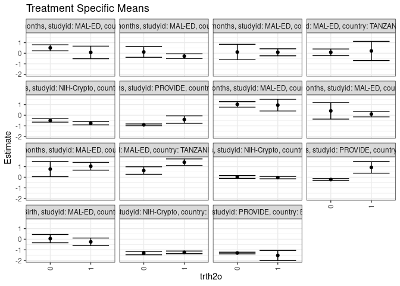

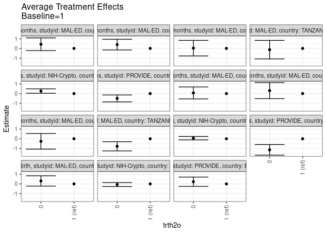

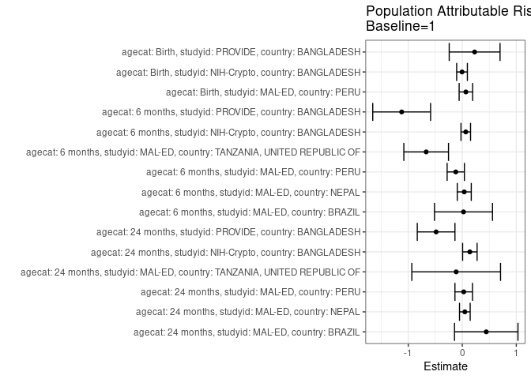

## Results Table

### Parameter: TSM

| agecat | studyid | country | intervention_level | baseline_level | estimate | ci_lower | ci_upper |
| --- | --- | --- | --- | --- | --- | --- | --- |
| Birth | MAL-ED | PERU | 1 | NA | -0.2460714 | -0.6028599 | 0.1107170 |
| Birth | MAL-ED | PERU | 0 | NA | 0.0550000 | -0.3367180 | 0.4467180 |
| Birth | NIH-Crypto | BANGLADESH | 1 | NA | -1.2395389 | -1.3650340 | -1.1140437 |
| Birth | NIH-Crypto | BANGLADESH | 0 | NA | -1.3036865 | -1.4673866 | -1.1399863 |
| Birth | PROVIDE | BANGLADESH | 1 | NA | -1.5271779 | -2.0017117 | -1.0526440 |
| Birth | PROVIDE | BANGLADESH | 0 | NA | -1.3003327 | -1.3782361 | -1.2224292 |
| 6 months | MAL-ED | BRAZIL | 1 | NA | 0.9503426 | 0.3967237 | 1.5039616 |
| 6 months | MAL-ED | BRAZIL | 0 | NA | 1.0192309 | 0.7600891 | 1.2783726 |
| 6 months | MAL-ED | NEPAL | 1 | NA | 0.1078812 | -0.1550846 | 0.3708469 |
| 6 months | MAL-ED | NEPAL | 0 | NA | 0.4135456 | -0.3629804 | 1.1900715 |
| 6 months | MAL-ED | PERU | 1 | NA | 1.0313707 | 0.6651332 | 1.3976081 |
| 6 months | MAL-ED | PERU | 0 | NA | 0.7653990 | 0.0521636 | 1.4786345 |
| 6 months | MAL-ED | TANZANIA, UNITED REPUBLIC OF | 1 | NA | 1.4100000 | 1.0960519 | 1.7239481 |
| 6 months | MAL-ED | TANZANIA, UNITED REPUBLIC OF | 0 | NA | 0.6305093 | 0.2775495 | 0.9834691 |
| 6 months | NIH-Crypto | BANGLADESH | 1 | NA | -0.0350136 | -0.1497139 | 0.0796867 |
| 6 months | NIH-Crypto | BANGLADESH | 0 | NA | 0.0212772 | -0.1119045 | 0.1544589 |
| 6 months | PROVIDE | BANGLADESH | 1 | NA | 0.9225268 | 0.3812019 | 1.4638517 |
| 6 months | PROVIDE | BANGLADESH | 0 | NA | -0.2201694 | -0.3032634 | -0.1370753 |
| 24 months | MAL-ED | BRAZIL | 1 | NA | 0.0767845 | -0.5154414 | 0.6690104 |
| 24 months | MAL-ED | BRAZIL | 0 | NA | 0.5073791 | 0.2250669 | 0.7896914 |
| 24 months | MAL-ED | NEPAL | 1 | NA | -0.2738854 | -0.4916380 | -0.0561328 |
| 24 months | MAL-ED | NEPAL | 0 | NA | 0.1192828 | -0.3826306 | 0.6211963 |
| 24 months | MAL-ED | PERU | 1 | NA | 0.0881517 | -0.2420237 | 0.4183272 |
| 24 months | MAL-ED | PERU | 0 | NA | 0.1126026 | -0.6153653 | 0.8405704 |
| 24 months | MAL-ED | TANZANIA, UNITED REPUBLIC OF | 1 | NA | 0.2166667 | -0.6845675 | 1.1179009 |
| 24 months | MAL-ED | TANZANIA, UNITED REPUBLIC OF | 0 | NA | 0.0854054 | -0.2281139 | 0.3989247 |
| 24 months | NIH-Crypto | BANGLADESH | 1 | NA | -0.7506013 | -0.9084937 | -0.5927090 |
| 24 months | NIH-Crypto | BANGLADESH | 0 | NA | -0.4914023 | -0.6507454 | -0.3320592 |
| 24 months | PROVIDE | BANGLADESH | 1 | NA | -0.4087434 | -0.7567734 | -0.0607134 |
| 24 months | PROVIDE | BANGLADESH | 0 | NA | -0.9059813 | -0.9903061 | -0.8216566 |

### Parameter: E(Y)

| agecat | studyid | country | intervention_level | baseline_level | estimate | ci_lower | ci_upper |
| --- | --- | --- | --- | --- | --- | --- | --- |
| Birth | MAL-ED | PERU | NA | NA | -0.1791667 | -0.4729428 | 0.1146094 |
| Birth | NIH-Crypto | BANGLADESH | NA | NA | -1.2441513 | -1.3281130 | -1.1601897 |
| Birth | PROVIDE | BANGLADESH | NA | NA | -1.2984586 | -1.3752758 | -1.2216415 |
| 6 months | MAL-ED | BRAZIL | NA | NA | 0.9731715 | 0.7347562 | 1.2115869 |
| 6 months | MAL-ED | NEPAL | NA | NA | 0.1447189 | -0.1029021 | 0.3923399 |
| 6 months | MAL-ED | PERU | NA | NA | 0.9109184 | 0.5934529 | 1.2283839 |
| 6 months | MAL-ED | TANZANIA, UNITED REPUBLIC OF | NA | NA | 0.7418651 | 0.4248303 | 1.0588998 |
| 6 months | NIH-Crypto | BANGLADESH | NA | NA | 0.0297622 | -0.0491685 | 0.1086930 |
| 6 months | PROVIDE | BANGLADESH | NA | NA | -0.1990907 | -0.2817968 | -0.1163845 |
| 24 months | MAL-ED | BRAZIL | NA | NA | 0.5203560 | 0.2632846 | 0.7774274 |
| 24 months | MAL-ED | NEPAL | NA | NA | -0.2262651 | -0.4277663 | -0.0247638 |
| 24 months | MAL-ED | PERU | NA | NA | 0.1148299 | -0.1831101 | 0.4127700 |
| 24 months | MAL-ED | TANZANIA, UNITED REPUBLIC OF | NA | NA | 0.1037209 | -0.1942394 | 0.4016813 |
| 24 months | NIH-Crypto | BANGLADESH | NA | NA | -0.6103502 | -0.7050157 | -0.5156847 |
| 24 months | PROVIDE | BANGLADESH | NA | NA | -0.8928670 | -0.9755153 | -0.8102187 |

### Parameter: ATE

| agecat | studyid | country | intervention_level | baseline_level | estimate | ci_lower | ci_upper |
| --- | --- | --- | --- | --- | --- | --- | --- |
| Birth | MAL-ED | PERU | 1 | 1 | 0.0000000 | 0.0000000 | 0.0000000 |
| Birth | MAL-ED | PERU | 0 | 1 | 0.3010714 | -0.2287785 | 0.8309214 |
| Birth | NIH-Crypto | BANGLADESH | 1 | 1 | 0.0000000 | 0.0000000 | 0.0000000 |
| Birth | NIH-Crypto | BANGLADESH | 0 | 1 | -0.0641476 | -0.2714307 | 0.1431355 |
| Birth | PROVIDE | BANGLADESH | 1 | 1 | 0.0000000 | 0.0000000 | 0.0000000 |
| Birth | PROVIDE | BANGLADESH | 0 | 1 | 0.2268452 | -0.2551522 | 0.7088426 |
| 6 months | MAL-ED | BRAZIL | 1 | 1 | 0.0000000 | 0.0000000 | 0.0000000 |
| 6 months | MAL-ED | BRAZIL | 0 | 1 | 0.0688882 | -0.5450905 | 0.6828670 |
| 6 months | MAL-ED | NEPAL | 1 | 1 | 0.0000000 | 0.0000000 | 0.0000000 |
| 6 months | MAL-ED | NEPAL | 0 | 1 | 0.3056644 | -0.5213387 | 1.1326675 |
| 6 months | MAL-ED | PERU | 1 | 1 | 0.0000000 | 0.0000000 | 0.0000000 |
| 6 months | MAL-ED | PERU | 0 | 1 | -0.2659716 | -1.0732715 | 0.5413282 |
| 6 months | MAL-ED | TANZANIA, UNITED REPUBLIC OF | 1 | 1 | 0.0000000 | 0.0000000 | 0.0000000 |
| 6 months | MAL-ED | TANZANIA, UNITED REPUBLIC OF | 0 | 1 | -0.7794907 | -1.2518720 | -0.3071095 |
| 6 months | NIH-Crypto | BANGLADESH | 1 | 1 | 0.0000000 | 0.0000000 | 0.0000000 |
| 6 months | NIH-Crypto | BANGLADESH | 0 | 1 | 0.0562908 | -0.1190877 | 0.2316693 |
| 6 months | PROVIDE | BANGLADESH | 1 | 1 | 0.0000000 | 0.0000000 | 0.0000000 |
| 6 months | PROVIDE | BANGLADESH | 0 | 1 | -1.1426962 | -1.6903556 | -0.5950368 |
| 24 months | MAL-ED | BRAZIL | 1 | 1 | 0.0000000 | 0.0000000 | 0.0000000 |
| 24 months | MAL-ED | BRAZIL | 0 | 1 | 0.4305946 | -0.2235977 | 1.0847869 |
| 24 months | MAL-ED | NEPAL | 1 | 1 | 0.0000000 | 0.0000000 | 0.0000000 |
| 24 months | MAL-ED | NEPAL | 0 | 1 | 0.3931682 | -0.1572073 | 0.9435438 |
| 24 months | MAL-ED | PERU | 1 | 1 | 0.0000000 | 0.0000000 | 0.0000000 |
| 24 months | MAL-ED | PERU | 0 | 1 | 0.0244508 | -0.7789425 | 0.8278442 |
| 24 months | MAL-ED | TANZANIA, UNITED REPUBLIC OF | 1 | 1 | 0.0000000 | 0.0000000 | 0.0000000 |
| 24 months | MAL-ED | TANZANIA, UNITED REPUBLIC OF | 0 | 1 | -0.1312613 | -1.0854716 | 0.8229491 |
| 24 months | NIH-Crypto | BANGLADESH | 1 | 1 | 0.0000000 | 0.0000000 | 0.0000000 |
| 24 months | NIH-Crypto | BANGLADESH | 0 | 1 | 0.2591991 | 0.0360520 | 0.4823461 |
| 24 months | PROVIDE | BANGLADESH | 1 | 1 | 0.0000000 | 0.0000000 | 0.0000000 |
| 24 months | PROVIDE | BANGLADESH | 0 | 1 | -0.4972380 | -0.8548360 | -0.1396400 |

### Parameter: PAR

| agecat | studyid | country | intervention_level | baseline_level | estimate | ci_lower | ci_upper |
| --- | --- | --- | --- | --- | --- | --- | --- |
| Birth | MAL-ED | PERU | 1 | NA | 0.0669048 | -0.0579283 | 0.1917378 |
| Birth | NIH-Crypto | BANGLADESH | 1 | NA | -0.0046125 | -0.1035996 | 0.0943747 |
| Birth | PROVIDE | BANGLADESH | 1 | NA | 0.2287192 | -0.2416988 | 0.6991373 |
| 6 months | MAL-ED | BRAZIL | 1 | NA | 0.0228289 | -0.5140413 | 0.5596991 |
| 6 months | MAL-ED | NEPAL | 1 | NA | 0.0368377 | -0.0927876 | 0.1664631 |
| 6 months | MAL-ED | PERU | 1 | NA | -0.1204523 | -0.2802290 | 0.0393244 |
| 6 months | MAL-ED | TANZANIA, UNITED REPUBLIC OF | 1 | NA | -0.6681349 | -1.0815518 | -0.2547181 |
| 6 months | NIH-Crypto | BANGLADESH | 1 | NA | 0.0647758 | -0.0236246 | 0.1531762 |
| 6 months | PROVIDE | BANGLADESH | 1 | NA | -1.1216175 | -1.6570951 | -0.5861399 |
| 24 months | MAL-ED | BRAZIL | 1 | NA | 0.4435715 | -0.1437246 | 1.0308676 |
| 24 months | MAL-ED | NEPAL | 1 | NA | 0.0476203 | -0.0510201 | 0.1462608 |
| 24 months | MAL-ED | PERU | 1 | NA | 0.0266782 | -0.1358117 | 0.1891681 |
| 24 months | MAL-ED | TANZANIA, UNITED REPUBLIC OF | 1 | NA | -0.1129457 | -0.9341257 | 0.7082342 |
| 24 months | NIH-Crypto | BANGLADESH | 1 | NA | 0.1402511 | 0.0063990 | 0.2741033 |
| 24 months | PROVIDE | BANGLADESH | 1 | NA | -0.4841236 | -0.8326613 | -0.1355860 |